# Citigrapher #2: Navigating the London tube network

OJ Watson

07 June, 2017

## Overview

1. Data from Citygrapher 1
2. Minimum Spanning Trees and Steiner Trees
3. Storage & Extension

Citigrapher is a tool that will help choose an optimum destination for a group of users based on what activity they want to do, and where they all live and work. The optimum destination is thus one that has a good option of activites, such as restaurants, pubs, music venues, museums etc, and ensure that the travel time for everyone is equally spread, so that no one feels left out.

In this chapter, these 3 parts will pick up from the last session where we used Google maps APIs to find the nearest 3 tubes to a list of user requested postcodes. These postcodes represented where our users were starting and ending their day, and tus the travel time to these tubes was stored so we know to include this when working out the travel time for each user when we have decided on a potential optimum tube stop.

We will then use these tubes to create a sub section of the London tube network that connects all our users, and thus must contain the optimum tube. This sub-network can then be searched (in the next Citigrapher section) to find out each user’s travel time for each tube stop in this network to create a ranked list of tube stops, which can then be used to query for a venue.

## 1. Data from Citygrapher 1

In this meetup we will be using the R package *igraph* to find the section of the London tube network that connects all our users. To begin with we will load the required package and then read in our saved data from last time

The first thing we need to do is load the data from last time. This data has been saved within the inst/extdata folder as *“tubes.rds”*. For those who have not seen a *“.rds”* file type before, it is simply a saved R object and can be read in as follows:

```r
## first let's install the necessary packages
install.packages("igraph",repos = "https://cloud.r-project.org/")
require(igraph)

## Read in the saved tube data
tubes  <- readRDS("inst/extdata/tubes.rds")
```

The tubes R object is a list of lists with a length of 3, which contains information relating to our 3 users. Each internal list shows the start and end location for user as both their postcode, which they provided, and theit latitidue and longitude, which we looked up last time. It also then shows the closest 3 tubes to these locations and the walking travel time in seconds. Let’s have a look at this data again to refamiliarise ourselves.

```r
## View the saved tube data
str(tubes)
```

```
## List of 3
##  $ :List of 5
##   ..$ Location               :List of 6
##   .. ..$ Start    : chr "W12 0RQ"
##   .. ..$ End      : chr "SW16 5YR"
##   .. ..$ StartLat : num 51.5
##   .. ..$ StartLong: num -0.238
##   .. ..$ EndLat   : num 51.4
##   .. ..$ EndLong  : num -0.146
##   ..$ StartTubes             : chr [1:3] "east acton" "shepherd's bush (h)" "white city"
##   ..$ EndTubes               : chr [1:3] "tooting broadway" "tooting bec" "balham"
##   ..$ StartTubesDistanceTimes: int [1:3] 801 1081 1052
##   ..$ EndTubesDistanceTimes  : int [1:3] 2468 2833 3138
##  $ :List of 5
##   ..$ Location               :List of 6
##   .. ..$ Start    : chr "NW1 7DB"
##   .. ..$ End      : chr "E1 0AA"
##   .. ..$ StartLat : num 51.5
##   .. ..$ StartLong: num -0.147
##   .. ..$ EndLat   : num 51.5
##   .. ..$ EndLong  : num -0.0521
##   ..$ StartTubes             : chr [1:3] "camden town" "chalk farm" "mornington crescent"
##   ..$ EndTubes               : chr [1:3] "shadwell" "wapping" "stepney green"
##   ..$ StartTubesDistanceTimes: int [1:3] 291 656 770
##   ..$ EndTubesDistanceTimes  : int [1:3] 451 896 1064
##  $ :List of 5
##   ..$ Location               :List of 6
##   .. ..$ Start    : chr "SW11 1QN"
##   .. ..$ End      : chr "SE17 1JE"
##   .. ..$ StartLat : num 51.5
##   .. ..$ StartLong: num -0.167
##   .. ..$ EndLat   : num 51.5
##   .. ..$ EndLong  : num -0.0964
##   ..$ StartTubes             : chr [1:3] "clapham south" "balham" "tooting bec"
##   ..$ EndTubes               : chr [1:3] "elephant & castle" "kennington" "borough"
##   ..$ StartTubesDistanceTimes: int [1:3] 1557 2106 2537
##   ..$ EndTubesDistanceTimes  : int [1:3] 676 599 1427
```

## 2. Minimum Spanning Trees and Steiner Trees

In this section we will be using the R package *igraph* to find the section of the London tube network that connects all our users. First we will read in the london tube network.

```r
## Now let's read in the tube map and call it object g for graph
g <- readRDS("inst/extdata/tubemap.rds")

## And let's have a look at what type of R object the tube map is
g
```

```
## IGRAPH DNW- 306 1546 --
## + attr: name (v/c), latitude (v/n), longitude (v/n), name.clean
## | (v/c), name.display (v/c), zone (v/n), dist (e/n), line.name
## | (e/c), line.colour (e/c), line.stripe (e/c), weight (e/n)
## + edges (vertex names):
##  [1] baker street    ->marylebone       baker street    ->marylebone
##  [3] baker street    ->regent's park    baker street    ->regent's park
##  [5] charing cross   ->embankment       charing cross   ->embankment
##  [7] charing cross   ->embankment       charing cross   ->embankment
##  [9] charing cross   ->picadilly circus charing cross   ->picadilly circus
## [11] edgware road (b)->marylebone       edgware road (b)->paddington
## + ... omitted several edges
```

The tube map is an igraph class object. An igraph object contains information, known as attriutes, relating to the *vertices* (tube stops) and the *edges* (tube lines) within the tube map, and which edges connect which vertices. So we can see for this graph object we now the *latitude*, *longitude*, *name* and *zone* of the tube stops, and then also the distance, line *name*, *colour* and *stripe colour* of the tube lines. We also have an attribute called *weight* that is the same as dist.

The *igraph* package allows us to plot the tube map so we can see what we’re looking at. For those who have not seen the use of “::” before, this simply shows that the fucntion after the “::” is within the namespace of the package listed before the “::”. I tend to include these as it makes it clearer where the function is coming from. You can, however, use it without if the package is loaded, which it is due to *require(igraph)* and thus *plot(g)* would also work with the correct plotting function being used based on the class of the object g.

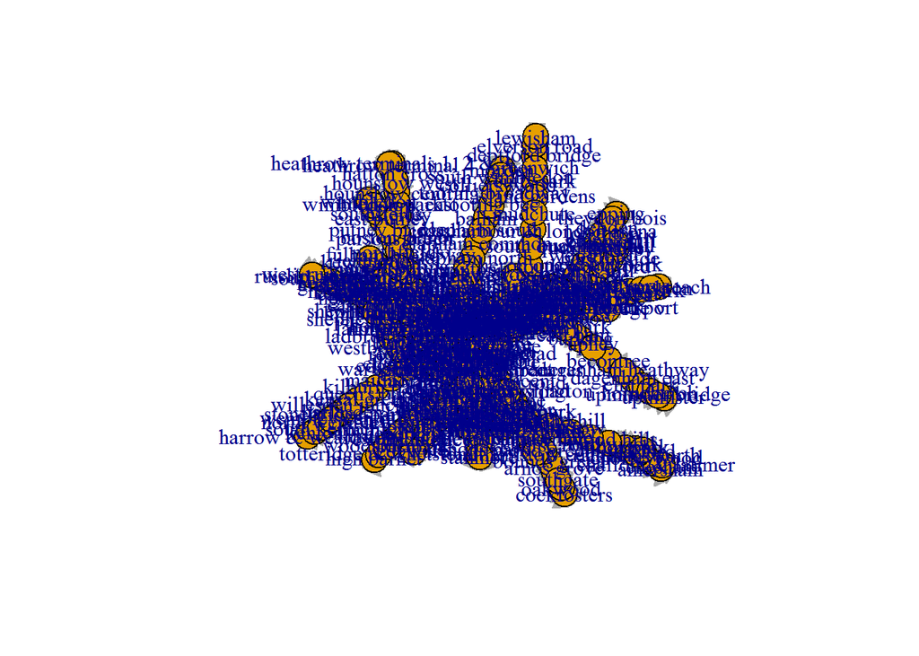

```r
## First plot the tube map as it is
igraph::plot.igraph(g)
```

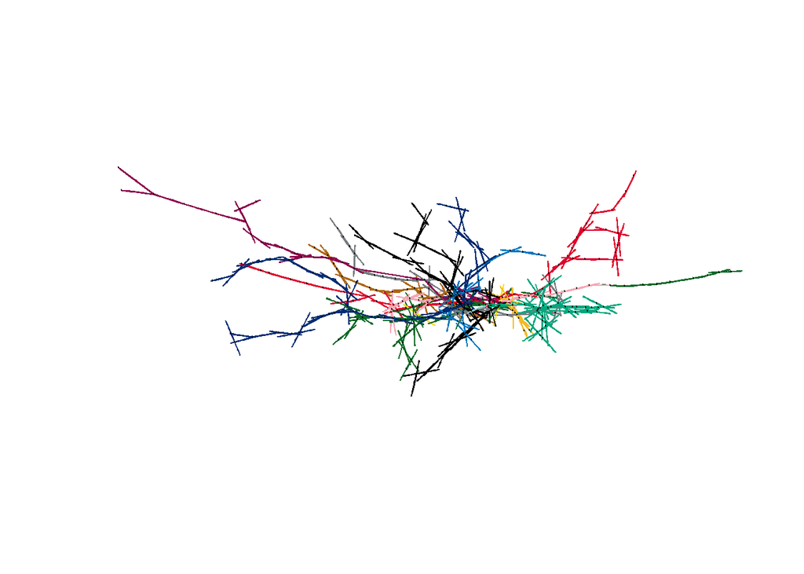

```r
## Now let's plot the tube map specifying some plotting variables
igraph::plot.igraph(g,layout=as.matrix(cbind(V(g)$longitude,V(g)$latitude)),
                        vertex.label=NA,vertex.label.cex=0,vertex.size=0,
                        edge.color=E(g)$line.colour,edge.arrow.width=0,edge.curved=FALSE,
                        rescale=FALSE,
                        xlim=c(min(V(g)$longitude),max(V(g)$longitude)),
                        ylim=c(min(V(g)$latitude),max(V(g)$latitude)))
```

We can see in the first plot that it’s not very clear. This is because the plot function simply plots the connects with an equal length and then optimises the layout. The second plotting function fixes the vertices in terms of the longitude and latitude, before colouring the edges by the tube line, and then scales it so it all fits within the plotting window. (Otherwise it would try to fit everything in a [-1,1] square, whereas our latitude in London is ~50)

Now we will want to create a Steiner Tree. There are many types of steiner tree, but paraphrasing it is how a group of vertices within the graph interconnect in some optimal way. For example, given our list of tubes a steiner tree would be the set of tube lnes that connect all these tubes in the shortest distance. For the purposes of today, however, we will be creating a list of connections between the tube stops listed within the tubes object using our tube map graph, but we will not be optimising their connection. This is partly because this a difficult combinatorial optimisation problem and because ultimately we are trying to eventually find a few tube stops that connect all our tubes, which is a slightly different problem.

To do this we will follow the first 3 of 5 steps of Kou’s algorithm to creating a Steiner Tree, the last 2 of which involve the optimisation and thus we ignore. If anyone is interested the paper where this was introduced can be found [here] (https://www.researchgate.net/publication/227056882_A_Fast_Algorithm_for_Steiner_Trees), which combined with the wikipedia page for Steiner trees gives plenty of overview.

To begin with we will want to create a new graph that connects all our tube stops.

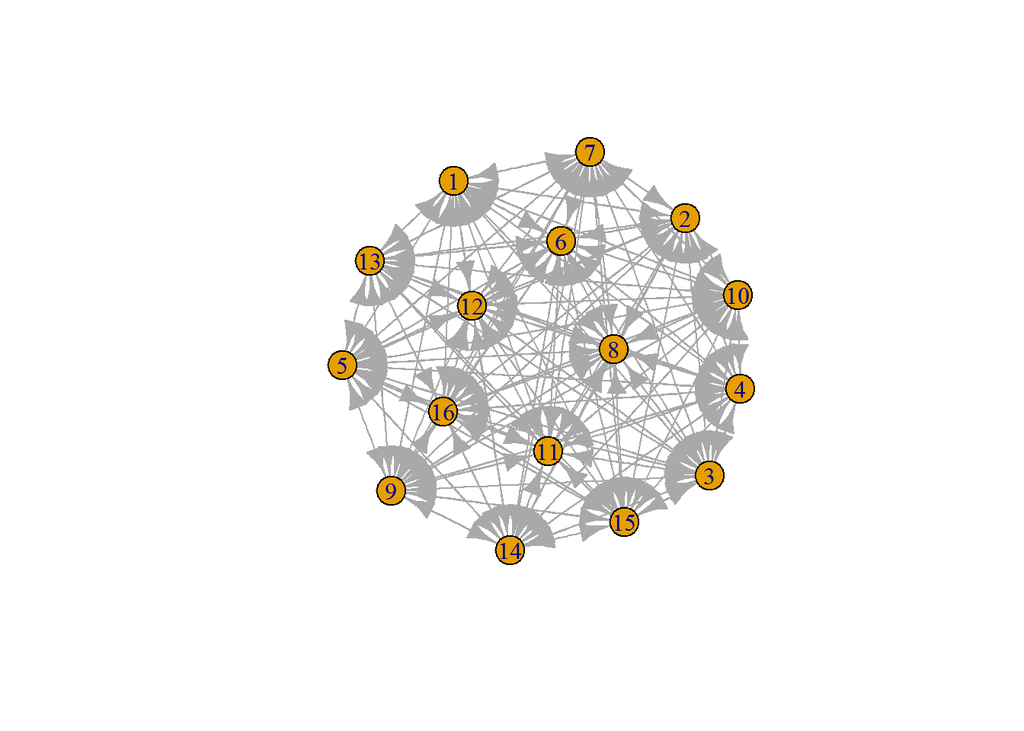

```r
## First let's extract all the tubes from our tubes object
# N.B. the %>% is contained within teh igraph package, and is simply exported
# from the magrittr package where it is found. It simply allows us to pass the
# the output from the LHS to be the input of the RHS

all_tubes <- lapply(tubes,function(x){
  return((rbind(x$StartTubes,x$EndTubes)))
}) %>% unlist %>% unique

## Next let's create a new graph that connects all our tubes and call it gi
gi <- igraph::graph.full(length(all_tubes),directed = TRUE)

## What does this look like
igraph::plot.igraph(gi)
```

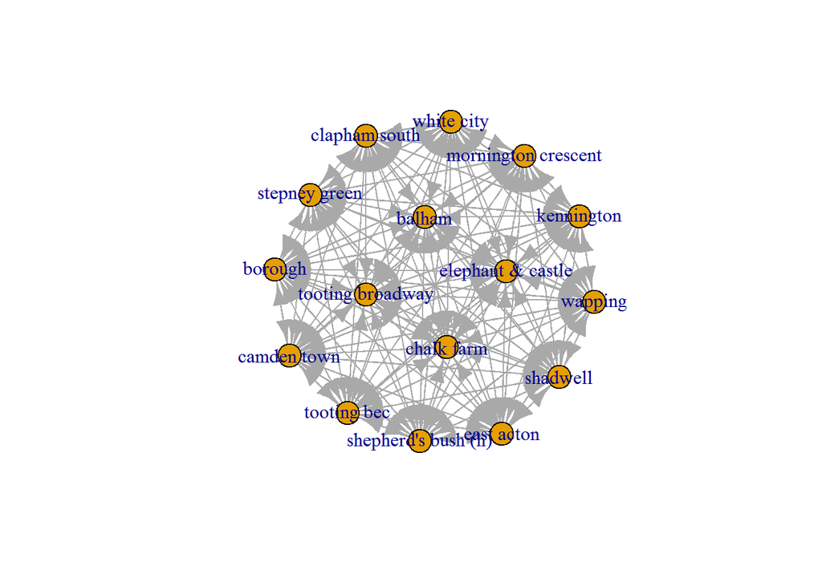

```r
## Let's now label the graph vertices with our tube names
igraph::V(gi)$name <- all_tubes

## And plot again
igraph::plot.igraph(gi)
```

What we have done above is create a graph that connects all the certices to each other. The graph we have created is directed, which means that going from A to B is different from B to A, which is important as some tube travel times are (apparantly accroding to tfl) different each way. We have then labelled them with the tube names, using *V(gi)$name*, which selects all the vertices with *V(gi)* ad then assigns a new attribute called *name*. The function *E()* does the same for edges. These function are used a lots below and as such I have not used the “::”.

Next we will create from that a minimum spanning tree (mst), which is the shortest way of connecting all the vertices given the edges, and then collect the edges within this.

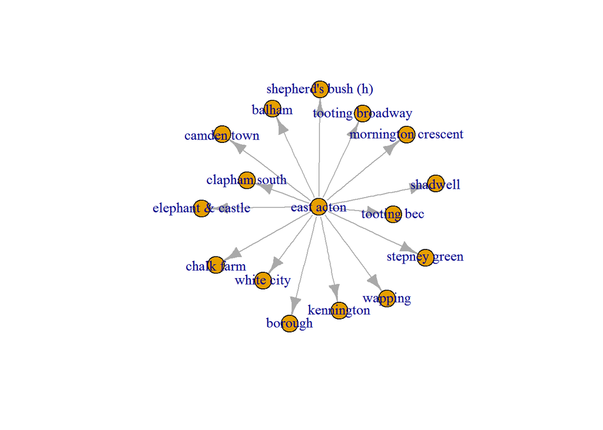

```r
## Create the mst
mst <- igraph::minimum.spanning.tree(gi)

## What does this look like
igraph::plot.igraph(mst)
```

```r
##  Let's now grapb teh list of edges within the mst
edge_list <- igraph::get.edgelist(mst)

## quickly view what the edge_list object looks like now
head(edge_list)
```

```
##      [,1]         [,2]
## [1,] "east acton" "tooting broadway"
## [2,] "east acton" "shepherd's bush (h)"
## [3,] "east acton" "tooting bec"
## [4,] "east acton" "white city"
## [5,] "east acton" "balham"
## [6,] "east acton" "camden town"
```

The next step is the longest, and seeks to replace each of the edges in the mst with the shortest path that connects these edges within the actual tube map. To do this we will loop over the edge list, search if there is a connection between them (which there always will be as the tube map is fully connected), and then look up the shortest path between them. Then we will replace the edge within the mst with this shortest path to produce the sub network we are looking for.

```r
## First create a copy of the mst
gs <- mst

## Loop through the edge list
for (n in 1:nrow(edge_list)) {

  ## What is the from (i) and to (j) from the nth row in the edge list
  i <- edge_list[n, 2]
  j <- edge_list[n, 1]

  ## Check that the edge from i to j is in fact within the tube map (always
  ## will be)
  if (length(igraph::E(gi)[which(V(mst)$name == i) %--% which(V(mst)$name == j)]) > 0) {

    ## If edge is present then remove existing edge from the minimum spanning
    ## tree copy:
    gs <- gs - E(gs)[which(V(mst)$name == i) %--% which(V(mst)$name == j)]

    ## Next extract the route, known as a subgraph, from g that corresponds to
    ## the shortest path

    shortest_path <- igraph::get.shortest.paths(g, from = V(g)[i], to = V(g)[j])

    g_sub <- igraph::induced.subgraph(g, shortest_path$vpath[[1]])

    ## Now join this subgraoh with our mst copy, thereby replacing the oringinal
    ## connection:
    gs <- igraph::union(gs, g_sub, byname = T)


    ## The following is for tidying up. In short, when we union two graphs we
    ## also copy the attributes across. If they have the same name then they are
    ## turned into attribute_1 and attribute_2. Every time, however, that we do
    ## this we eventually lose information about the attributes as they get
    ## overwritten. The following simply takes attribute_1 and attribute_2 and
    ## combines them to create teh required attribute and asssigns it to gs.

    ## concatenate duplicate attributes as they appear
    if (n > 1) {

      ## create the list of edge attributes and what the unreplicated versions are
      edge.ats <- list.edge.attributes(gs)
      edge.at.names <- lapply(strsplit(list.edge.attributes(gs), split = "_"),
        function(x) {
          return(x[[1]])
        }) %>% unlist %>% unique()

      ## do the same for vertex attributes, but remembering to remove name as this
      ## is never duplicated
      vert.ats <- list.vertex.attributes(gs)
      vert.at.names <- lapply(strsplit(list.vertex.attributes(gs), split = "_"),
        function(x) {
          return(x[[1]])
        }) %>% unlist %>% unique()
      vert.at.names <- vert.at.names[-which(vert.at.names == "name")]

      ## loop through duplicated attributes, combine them and then assign them to
      ## the graph
      for (e in edge.at.names) {
        attrs <- edge.attributes(gs)[grep(e, edge.ats)]
        mat <- cbind(attrs[[1]], attrs[[2]])
        gs <- set.edge.attribute(gs, e, value = apply(mat, MARGIN = 1,
          function(x) {
          return(ifelse(length(na.omit(x)) == 0, yes = NA, no = na.omit(x)))
          }))
      }

      for (v in vert.at.names) {
        attrs <- vertex.attributes(gs)[grep(v, vert.ats)]
        mat <- cbind(attrs[[1]], attrs[[2]])
        gs <- set.vertex.attribute(gs, v, value = apply(mat, MARGIN = 1,
          function(x) {
          return(ifelse(length(na.omit(x)) == 0, yes = NA, no = na.omit(x)))
          }))
      }

    }

  }

  ## Lastly remove the duplicates from the last iteration
  gs.vat.names <- list.vertex.attributes(gs)
  to.remove <- gs.vat.names[grep(pattern = "_", gs.vat.names)]
  for (i in to.remove) {
    gs <- igraph::delete_vertex_attr(gs, i)
  }

  gs.edge.names <- list.edge.attributes(gs)
  to.remove <- gs.edge.names[grep(pattern = "_", gs.edge.names)]
  for (i in to.remove) {
    gs <- igraph::delete_edge_attr(gs, i)
  }


}
```

The above will now have produced a subgraph that connects all our tubes in a way that does not include too many unnecessary other tube stops. Let’s have a look at that.

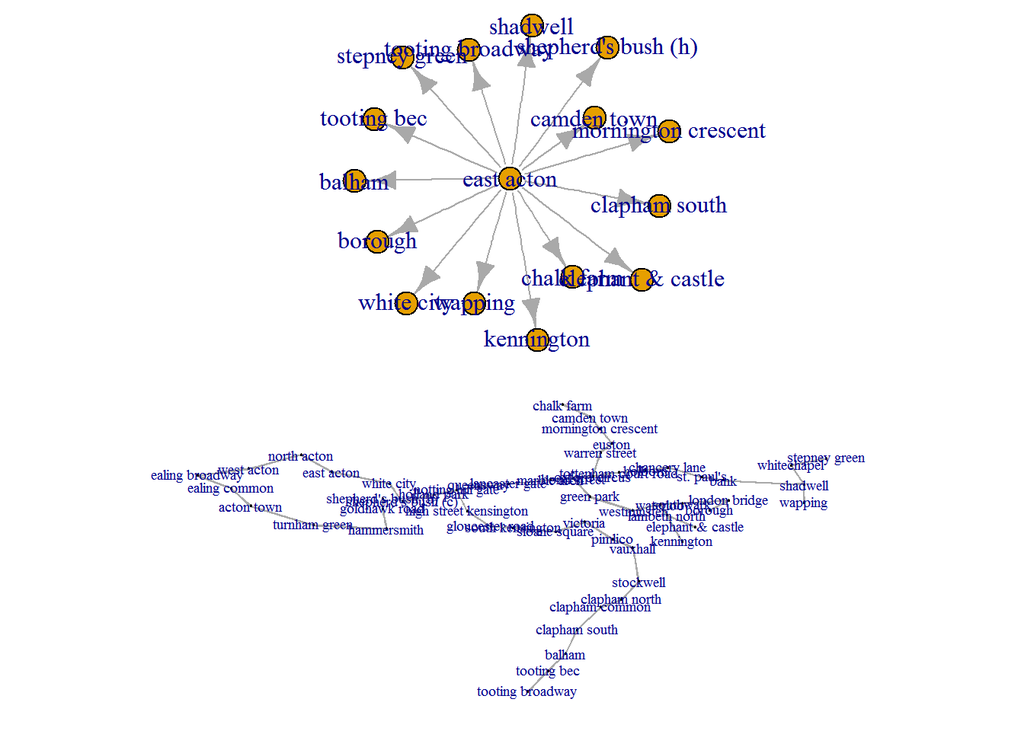

```r
## set up initial plot as 2 rows with no margins
par(mfrow=c(2,1))
par(mai=c(0,0,0,0))

## Plot original mst
igraph::plot.igraph(mst)

## Plot new subgraph with some graphical parameters
igraph::plot.igraph(gs,layout=as.matrix(cbind(V(gs)$longitude,V(gs)$latitude)),
     vertex.label.cex=0.6,edge.arrow.size=0.25,rescale=FALSE,
     xlim=c(min(V(gs)$longitude)*0.9998,max(V(gs)$longitude)*1.0002),
     ylim=c(min(V(gs)$latitude)*0.9998,max(V(gs)$latitude)*1.0002),
     edge.curved=FALSE,edge.arrow.width=0,vertex.size=0.1)
```

Now we can have a look to see how this relates to our original tube stop locations, to give some piece of mind that it actually looks sensible.

[figure not shown]

```r
## Plot new subgraph with some graphical parameters again
igraph::plot.igraph(gs, layout = as.matrix(cbind(V(gs)$longitude, V(gs)$latitude)),
    vertex.label.cex = 0.6, edge.arrow.size = 0.25, rescale = FALSE,
    xlim = c(min(V(gs)$longitude) * 0.9998, max(V(gs)$longitude) * 1.0002),
    ylim = c(min(V(gs)$latitude) * 0.9998, max(V(gs)$latitude) * 1.0002),
    edge.curved = FALSE, edge.arrow.width = 0,
    vertex.size = 0.1)


## Now let's create a new graph from our tube map points, i.e. 3x2
## vertices for each person
original.points <- igraph::make_empty_graph(n = 6, directed = TRUE)

## Add the latitude, longitude and name of these stops
V(original.points)$latitude <- lapply(tubes, function(x) {
    return((rbind(x$Location$StartLat, x$Location$EndLat)))
}) %>% unlist

V(original.points)$longitude <- lapply(tubes, function(x) {
    return((rbind(x$Location$StartLong, x$Location$EndLong)))
}) %>% unlist

V(original.points)$name <- c("A Start", "A End", "B Start",
                             "B End", "C Start", "C End")

## Now let's plot these on top
igraph::plot.igraph(original.points, layout = as.matrix(cbind(V(original.points)$longitude,
    V(original.points)$latitude)), vertex.label.cex = 1, vertex.size = 1,
    vertex.color = sort(replicate(2, heat.colors(3, alpha = 1))), rescale = FALSE,
    add = TRUE)

## And for niceness, let's plot the tube lines as well
igraph::plot.igraph(g, layout = as.matrix(cbind(V(g)$longitude, V(g)$latitude)),
    vertex.label = NA, vertex.label.cex = 0, vertex.size = 0, edge.color = E(g)$line.colour,
    edge.arrow.width = 0, edge.curved = FALSE, rescale = FALSE, xlim = c(min(V(g)$longitude),
        max(V(g)$longitude)), ylim = c(min(V(g)$latitude), max(V(g)$latitude)),
    add = TRUE)
```

In this plot, only tubes with labels are ones within our subgraph and we can see that they capture well where our users are based.

## 3. Storage and Extension

The last section is shorter and more open ended again for everyone to start thinking about how might be best to store data as citigrapher grows, and also how best to improve on this section.

Firstly, let’s save the object gs that we have created, so we can use it next time.

```r
## igraph saving as R object
saveRDS(gs,"inst/extdata/subgraph.rds")

## igraph saving as gml object that works well with the python networkx module
igraph::write.graph(gs,file = "inst/extdata/subgraph.graphML",format = "gml")
```

We also might want to start thinking about improvements to the above. Firstly, we can see that there are unnecessary tubes to the west of A_Start. This extra loop of tubes seems unlikely to be helpful, and results from having East Acton as our centre within the mst. Thus we could iterate around the mst process by adding the edge weights to the fully connected graph.

Going forward we will want to then start thinking about how we might search within this subgraph for the distance for each user to a tube stop. We could do this with brute force, iteratively going through each tube. This will take a long time so perhaps pruning our subgraph to not include this western loop might make sense. This represents some of the last steps within Kou’s algorithm. There are lots of other things that need to be extended at the moment (tube line changes, number of changes people want to make, night tube considerations etc), but hopefully we can start to see it taking shape.

## Summary

Hopefully the above tutorial has shown a framework in R of how we can start probing the london tube map as a graph object using the *igraph* package. As always if anyone has any other ideas, or ways of approaching this problem then let me know either as an issue in the github repo, or drop me a message. I hope this has been useful and interesting, and next time we will (probably) move to part 4 (as part 3 will be more graph theory so let’s keep it varied!) and start looking for how to search google for posible activities and ways of ranking them given we have a set of tube stops we are happy with as a result of part 3.